## title: “Github_Womens Machine learning”

#### output: html_document

**Created for Google Machine learning competition Final place 217/500 participants My graded Log loss score of .40367, winner scored .32245 log loss**

**Background:** On a scale of 0 to 1 predict percentage chance of a team winning a given tournament matchup for all potential matchups

**Data:** sets utilized will utilize regular season womens game by game stat numbers to predict performance in tournament

**Train Data:** 2010-2018 womens regular season data as predicting (independent) variables – use tournament performance as dependent variable

**Test Data:** 2019 regular season data - predict winning percentage chance by all 2016 potential games (64 teams x63 potential opponents/ 2 teams per game)

# *********************************************************************************************

### Section 1 - data manipulation and feature engineering based on a single teams standalone statistics

# *********************************************************************************************

Section 1a. : Strength of schedule data & data manipulation Purpose of this section is to create a strength of schedule measure Will be broken out by upset poential - i.e. how many quality ranked wins a team has Also will take into account consistency - i.e. general quality of losses, are they against good or bad teams

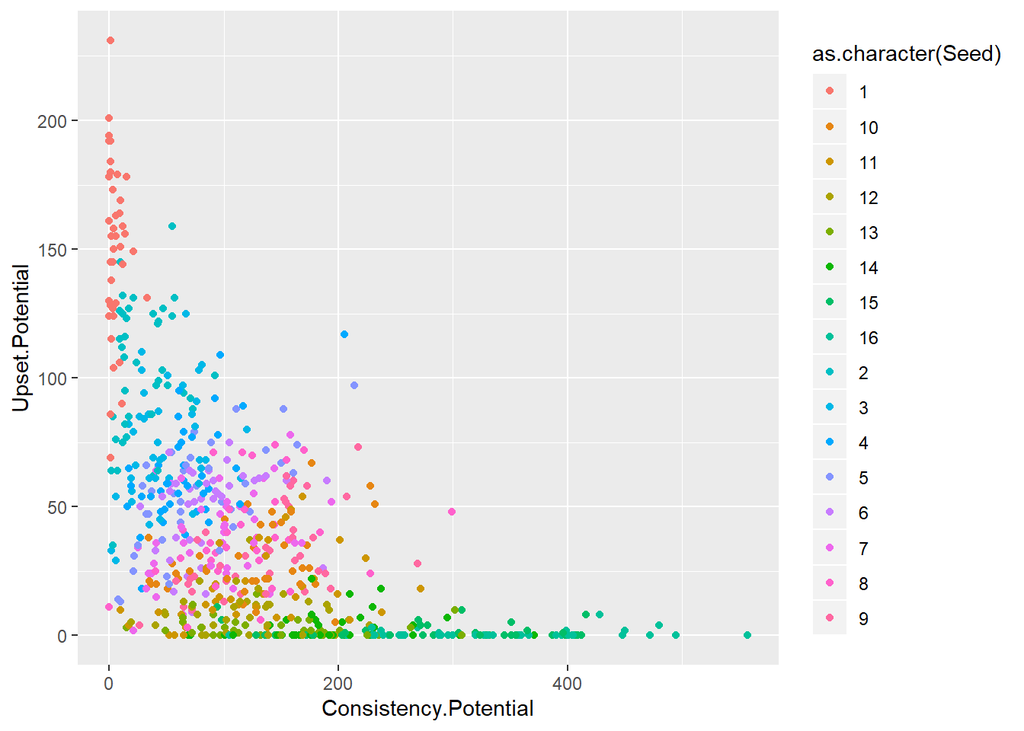

```r
#This plot highlights the features we created by looking at head to head wins and losses.  My consistency and upset potential features highly correlate with seeding
qplot(Consistency.Potential,Upset.Potential,colour = as.character(Seed),
      data = CombinedTeamGrouped)
```

Section 1b. : Create features based on advanced basketball statistics Look at things like Field goal pecentage, effective fg %, and field goal differential. In prior year challenge I simply used these features to create a simulated game score based on more advanced stats

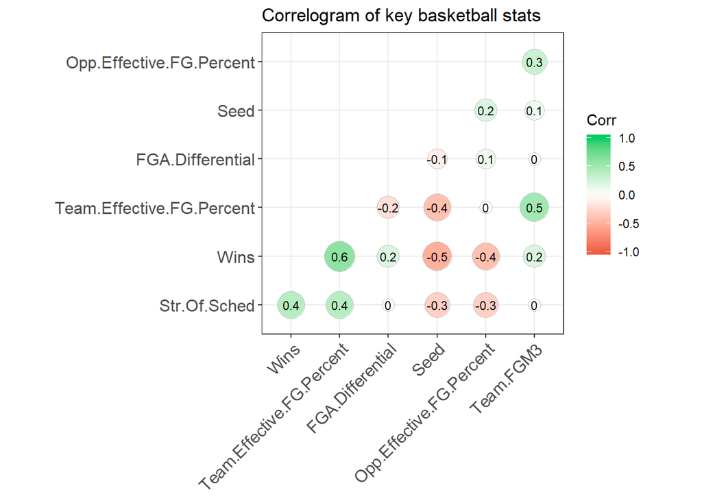

```r
# Correlation matrix
selection <- CombinedTeamGrouped[,c("Wins","Seed","Str.Of.Sched","Team.Effective.FG.Percent","FGA.Differential","Opp.Effective.FG.Percent","Team.FGM3")]
corr <- round(cor(selection), 1)
ggcorrplot(corr, hc.order = TRUE,
           type = "lower",
           lab = TRUE,
           lab_size = 3,
           method="circle",
           colors = c("tomato2", "white", "springgreen3"),
           title="Correlogram of key basketball stats",
           ggtheme=theme_bw)
```

# *********************************************************************************************

### Section 2 - Preparing data set for predictive model and feature engineering based on head to head statistics

# *********************************************************************************************

Section 2a. : Create data matrix that computes all possible games Compute theoretical game scores (The last feature we will engineer for our data set (Section 1)) Need to create all possible games by doing a join between the same data frames (Section 2)

# *********************************************************************************************

### Section 3 - Feature normalization and splitting datasets

Note: some feature engineering is included in this section as well as a way to improve random forest model (was done after initial runs)